# Sampling from a distribution with a known CDF

Jonny Law  
2019-02-25

A distribution with an inverse cumulative distribution function (CDF) can be sampled from using just samples from $U[0, 1]$. The inverse CDF (sometimes called the quantile function) is the value of $x$ such that $F_X(x) = Pr(X \leq x) = p$. Consider a that a transformation $g: [0, 1] \rightarrow \mathbb{R}$, exists which takes a value sampled from the standard uniform distribution $u \sim U[0, 1]$ and returns a value distributed according to the target distribution. Then the inverse CDF can be written as:

$$Pr(g(U) \leq x) = Pr(U \leq g^{-1}(x)) = g^{-1}(x)$$

Since the CDF of the uniform distribution over the interval $[0, 1]$ is:

$$\begin{align*}
F_U(u) =
\begin{cases}
0 & u < 0 \\
u & u \in [0, 1) \\
1 & u \geq 1
\end{cases}
\end{align*}$$

Then $F_x^{-1}(X) = g(x)$ as required. The algorithm below summarises the inverse sampling procedure.

1. Sample $u \sim U[0, 1]$
2. Evaluate $x = F^{-1}(u)$
3. Return $x$

Most statistical packages will expose the quantile function for common distributions making it practical to use inverse sampling. The figure below shows a histogram of 1,000 simulated values from a $\textrm{Gamma}(3, 4)$ distribution using the inverse CDF method, the analytical density is plotted in red.

The figure below shows samples from $\textrm{Gamma}(3, 4)$ using the inverse CDF method plotted with the analytical PDF.

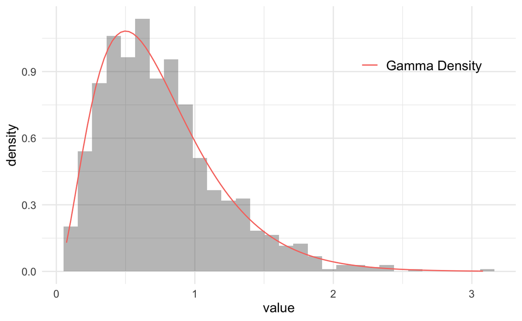

```r
inverse_cdf_sample <- function(inv_cdf) {
  u <- runif(1)
  inv_cdf(u)
}

inv_cdf <- function(x) qgamma(p = x, shape = 3, rate = 4)
gamma_samples <- replicate(1000, inverse_cdf_sample(inv_cdf))

ggplot(tibble(gamma_samples)) +
  geom_histogram(aes(x = gamma_samples, y = ..density..), alpha = 0.4) +
  stat_function(
    fun = function(x) dgamma(x, shape = 3, rate = 4),
    aes(colour = "Gamma Density")
  ) +
  theme(
    text = element_text(size = 12), legend.title = element_blank(),
    legend.text = element_text(size = rel(1.0)), legend.position = c(0.8, 0.8)
  ) +
  ylab("density") +
  xlab("value")
```